# Bloque 2: Árboles de probabilidad y Valor Esperado, aplicaciones de CART

Profesora: Dra. Diana Paola Montoya Escobar diana.montoya@iteso.mx

Febero 2022

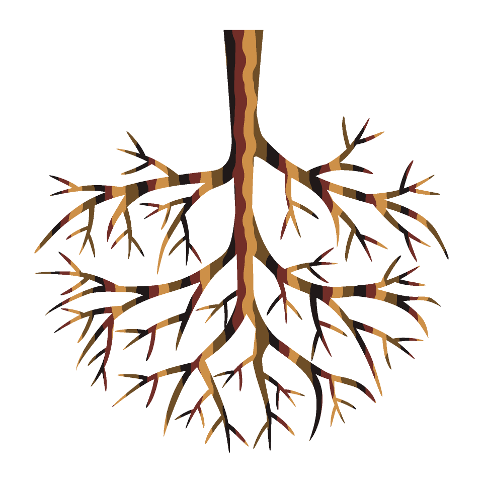

[figure not shown]

# Mejores decisiones con la teoría de las preferencias

*¿Cuál es la actitud de las empresas hacia el riesgo? ¿Se expresa claramente a su gerente? ¿Cómo incorporar esta actitud arriesgada en la toma de decisiones?*

Si la empresa es como la mayoría, su actitud de asunción de riesgos no se comprende con claridad ni se comunica adecuadamente. Y en ausencia de una política claramente establecida, es poco probable que las decisiones tomadas por los gerentes en varios niveles reflejen adecuadamente la actitud corporativa deseada. Incluso en aquellas situaciones en las que la política de toma de riesgos de la empresa se establece con mayor claridad, el grado en el que se incorpora adecuadamente en la toma de decisiones suele estar lejos del ideal.

## Decisiones y riesgos

La mayoría de los análisis formales de decisiones comerciales que involucran incertidumbre asumen que cada individuo o cada compañía tiene (o debería tener) la misma actitud hacia el riesgo. El supuesto es que, quien toma las decisiones, querrá elegir el curso de acción que tenga el valor de *beneficio esperado* más alto.

De ahí surge una definición muy importante que debemos de considerar: *el valor esperado*. *El valor esperado o expectativa matemática es el promedio ponderado de los posibles resultados anticipados de un curso de acción particular, donde los pesos son las probabilidades).* En otras palabras, el análisis generalmente asume que los tomadores de decisiones querrán “jugar los promedios” en todas las transacciones, independientemente de las posibles consecuencias negativas que puedan resultar. Pero, de hecho, como todo ejecutivo experimentado sabe, *muy pocos empresarios adoptan esta actitud ante el riesgo cuando toman decisiones importantes*.

Puede convencerse a sí mismo de esto respondiendo a la simple pregunta:

*¿Cuál es la cantidad máxima que estaría dispuesto a comprometer a su empresa a pagar por una probabilidad de 50% a 50% de ganar $500,000 o perder $100,000?*

Si usted es del tipo que juega con los promedios, su respuesta es $200,000 (es decir, .50 × $500,000 – 0,50 × $100,000), el valor esperado de la empresa. Pero si usted es como la mayoría de las personas, su respuesta es menos de $200,000, y quizás considerablemente menos, lo que refleja bastante bien su actitud hacia el riesgo.

*Lo que falta en la práctica, entonces, es un esquema formal para adaptar la técnica de toma de decisiones a la actitud de toma de riesgos del tomador de decisiones.*

Algunos de los creadores de esta metodología son FP Ramsey 3 y John Von Neumann 4; Leonard J. Savage, 5 Robert O. Schlaifer, 6 y muchos otros merecen crédito por su desarrollo.

## Caso de Petro Enterprises

Volvamos a este ejemplo, donde en resumen, nos indica que la cabeza de la empresa, William Snyder, debe tomar una decisión de sus pozos de petróleo.

Tiene tres principales decisiones:

1. Taladrar inmediatamente,
2. Pagar por una prueba sísmica y dependiendo del resultado, decidir si perforar o no, y
3. Dejar que la opción que le den caduque (no hacer nada).

Pero como todo tiene un costo y consideraciones:

- Dos pozos secos recientes en otros lugares han reducido los activos líquidos netos de Petro a $130,000 (este es el dinero que tiene actualmente y con el que se quedará si no hace nada).
- Se puede realizar la prueba sísmica con poca antelación a tarifas de horas extra por una tarifa fija de $30,000,
- El pozo se puede perforar por una tarifa fija de $100,000.
- Una gran compañía petrolera ha prometido que si Petro perfora y descubre petróleo, comprará todos los derechos de Petro por $400.000 dólares.

Además, un geólogo experto examinó la geología de la región y nos dió ciertas afirmaciones:

- Hay una probabilidad de 0.55 si se perfora que el pozo, que se encuentre petróleo.
- Si hacemos la prueba, y sale favorable, la probabilidad aumenta 0.85, pero si la prueba sale desfavorable, la probabilidad baja 0.10.
- También nos indicó que, hay una probabilidad del 0.60 de que el resultado de la prueba sea favorable.

Por tanto, este problema, lo podemos ver como un árbol de decisión:

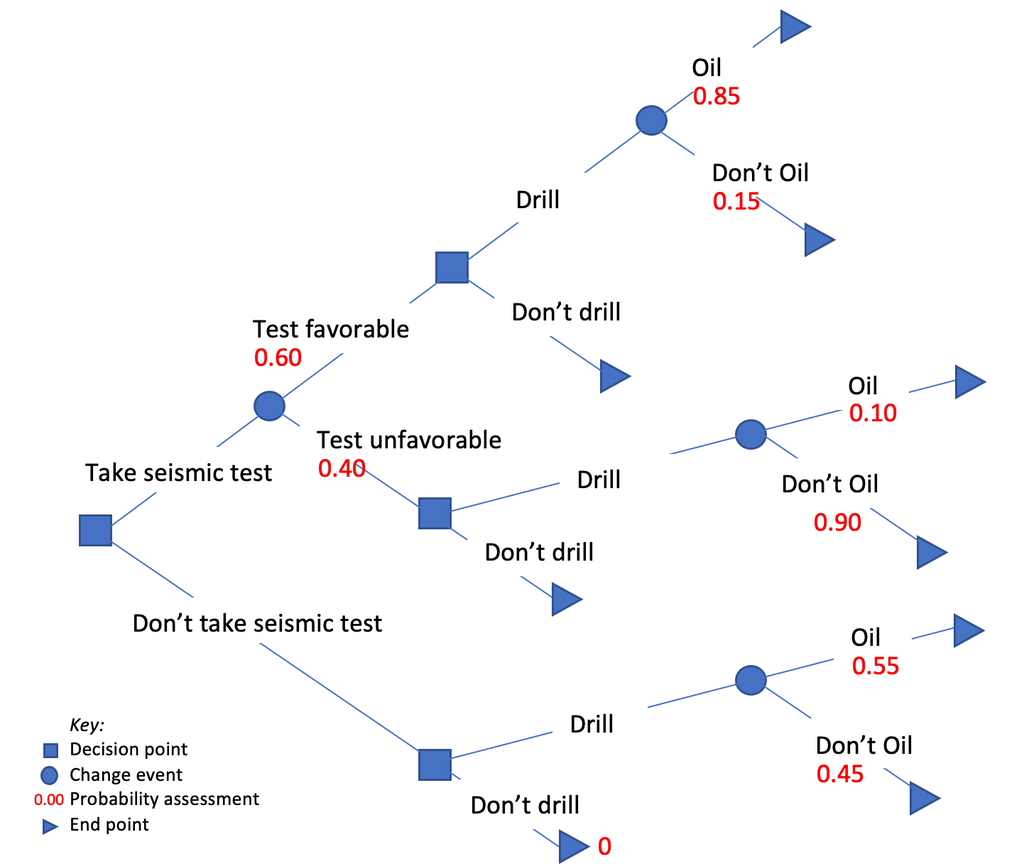

## Análisis del valor esperado

En la empresa de Petro Enterprises, ¿Cómo se analizaría el problema de Snyder asumiendo que está interesado en “jugar los promedios” y maximizar las ganancias o, más precisamente, que desea maximizar la expectativa matemática de su posición de activos (que es equivalente en este caso a maximizar la expectativa matemática)?

Podemos seguir estos pasos:

1. Determine las posiciones de activos que tendría Petro Enterprises si llegara a cada una de las nueve posiciones finales en el árbol de decisiones.
2. Determine la mejor estrategia de Petro trabajando hacia atrás a través del árbol; es decir, en cada bifurcación que representa un evento fortuito (llamado “bifurcación de evento”) calcula el valor esperado, y en cada bifurcación que representa una elección de acción (una “bifurcación de acto”) elige el acto que tiene el valor esperado más alto.

### Calcular posiciones de activos

Pasemos ahora a los números. El diagrama del problema de decisión, podemos poner el flujo de efectivo asociado con cada acto y evento en el diagrama. Por ejemplo, realizar la prueba sísmica cuesta $30,000, por lo que una salida de esta cantidad se indica escribiendo “- $30,000” por “Realice prueba sísmica”. De manera similar, la presencia de petróleo da como resultado una entrada de $400,000, por lo que esta cifra aparece por “Petróleo”.

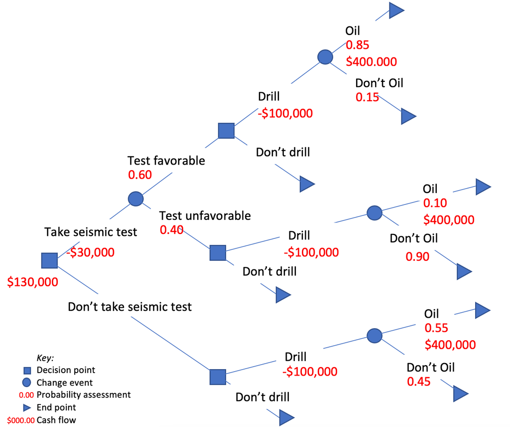

Podemos ver que tenemos 9 nodos finales (hojas del árbol), que representan los terminales de nueve posibles secuencias de actos y eventos.

### Flujos de efectivo

A cada uno corresponde una posición de activos para Petro Enterprises. Estas posiciones de activos se pueden calcular sumando los diversos flujos de efectivo desde el origen del diagrama hasta cada posición final y sumando el total a la posición de activos actual de la empresa de $130,000.

A continuación, veremos los resultados. Por ejemplo, la más alta de las nueve posiciones finales muestra una posición de activos de $400,000. Esta es la suma de los ingresos por el petróleo y la posición actual de los activos, menos los costos de realizar la prueba sísmica y la perforación. A continuación se presenta el flujo de activos junto con el árbol de decisión.

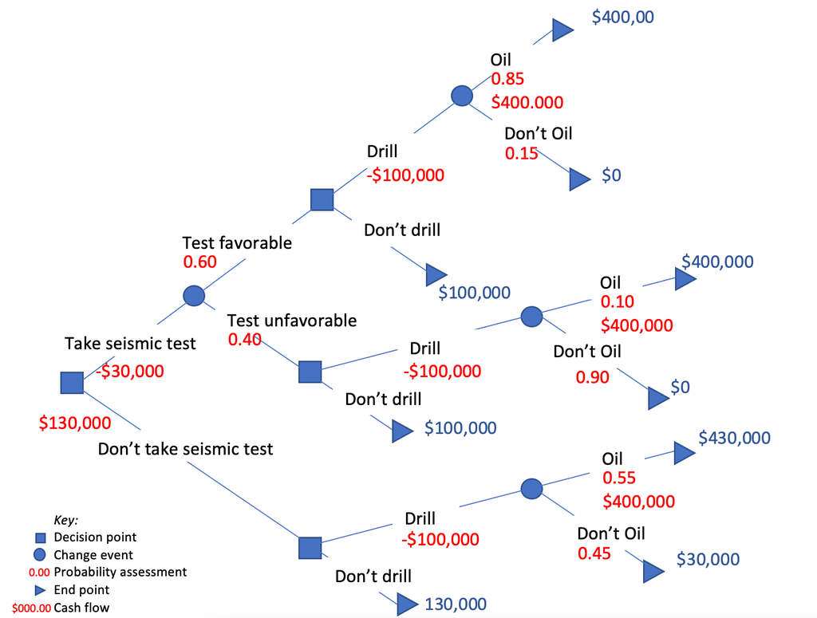

La cantidad económica que el tomador de decisiones usa para describir el resultado de un camino particular en su árbol de decisiones se llama criterio. En este caso, Snyder ha elegido un criterio de activos líquidos netos, ya que su posición de activos líquidos determina su capacidad para considerar operaciones futuras. Otros empresarios en otras situaciones bien podrían seleccionar ganancias, flujo de caja neto o algún otro criterio. Obviamente, el uso de diferentes criterios puede llevar a diferentes decisiones en algunas situaciones.

Algo que debemos de considerar es que podemos encontrar el valor ponderado por el riesgo de la decisión y si partimos de cualquier nodo hacia las ramas posteriores del árbol, siempre la probabilidad en conjunto nos dará el valor de *1*.

Veamos un ejemplo de ello para entenderlo mejor. Tomemos la rama después del que la prueba salga favorable y calculemos un resumen de cada una de las ramas hasta llegar al nodo final o hoja del árbol.

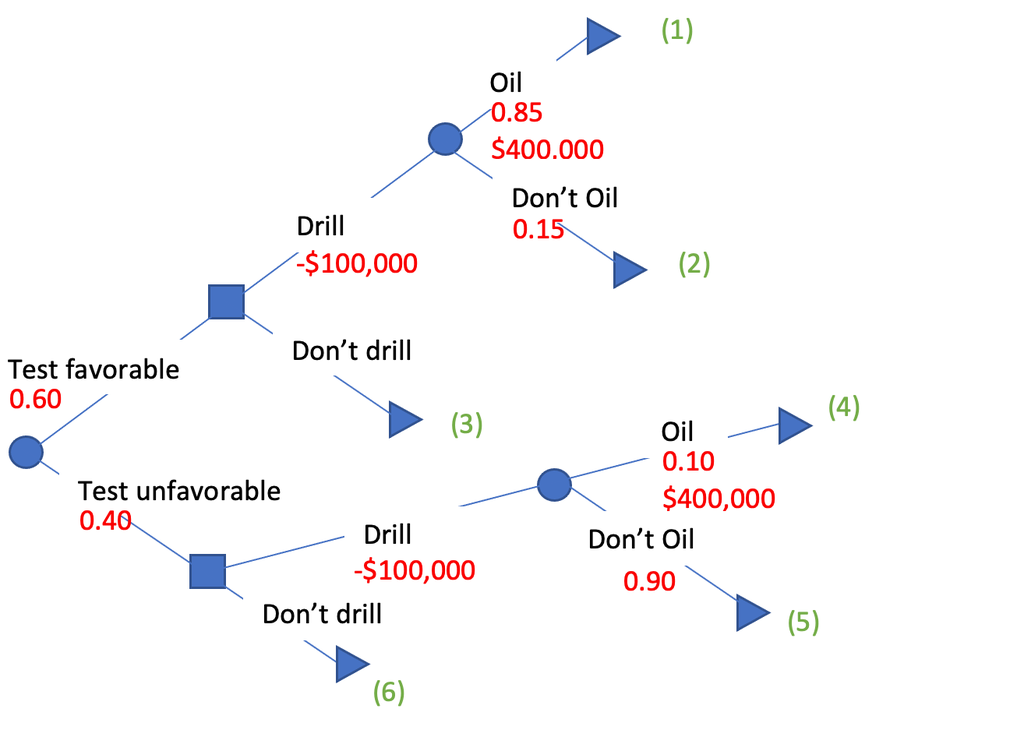

| Nodo final | p Test | Perforación | P Petróleo | Probabilidad rama |
| --- | --- | --- | --- | --- |
| 1 | 0.6 | 1 | 0.85 | 0.51 |
| 2 | 0.6 | 1 | 0.15 | 0.09 |
| 3 | 0.6 | 0 |  | 0.00 |
| 4 | 0.4 | 1 | 0.1 | 0.04 |
| 5 | 0.4 | 1 | 0.9 | 0.36 |
| 6 | 0.4 | 0 |  | 0.00 |
| Probabilidad del sub árbol |  |  |  | *1.00* |

### Expectativas y elecciones

Las bifurcaciones terminales en el árbol anterior son bifurcaciones de eventos que representan incertidumbre sobre los resultados de la perforación. En cada bifurcación terminal procedemos calculando el valor esperado de la posición de activos de la empresa, que es simplemente el promedio ponderado de los números en las posiciones finales que emanan de la bifurcación.

Tomando nuevamente la bifurcación terminal más alta como ilustración, el valor esperado es $340,000 (es decir, .85 × $400,000 + .15 × $0).

Un análisis basado en la expectativa matemática supone que Snyder aceptaría una posición de activos segura de $340,000 a cambio de una probabilidad de .85 de activos de $400,000 más una probabilidad de 0.15 de $0 en activos, y viceversa. En otras palabras, la posición del activo y la probabilidad son equivalentes. Más adelante discutiré el realismo de esta suposición, pero por el momento la aceptaremos porque nos permite reemplazar la bifurcación de eventos por su expectativa matemática. De hecho, dado que se supone que cada bifurcación de evento terminal es equivalente a su expectativa matemática, podemos descartar el conjunto terminal de bifurcaciones y reemplazarlas por sus expectativas matemáticas.

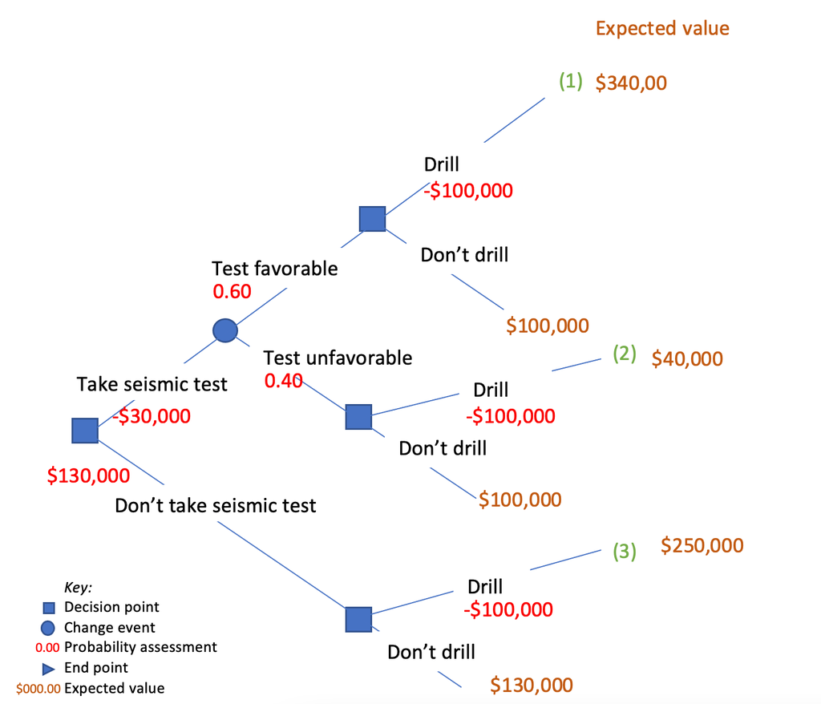

Las líneas 1,2,3 las podemos calcular de la siguiente forma:

|  | p petróleo | flujo efectivo | p no petróleo | Flujo Efectivo | Valor esperado |
| --- | --- | --- | --- | --- | --- |
| 1 | 0.85 | 400,000 | 0.15 | 0 | 340,000 |
| 2 | 0.1 | 400,000 | 0.9 | 0 | 40,000 |
| 3 | 0.55 | 430,000 | 0.45 | 30,000 | 250,000 |

Ahora los terminales son horquillas de acto donde la elección de Snyder es entre perforar y no perforar. Si está maximizando las expectativas matemáticas, su elección es fácil. Simplemente elige el acto con el valor esperado más alto.

Después de un resultado de prueba sísmica favorable, por ejemplo, la elección es entre perforar, con una expectativa matemática de $340,000, y no perforar, con una expectativa matemática de $100,000. Obviamente, Snyder debería decidir perforar.

Pero podemos seguir reduciendo nuestro árbol, la reducción de la bifurcación de eventos que representa el resultado de la prueba. El procedimiento es el mismo que con cualquier bifurcación de eventos; tomamos la expectativa matemática de los números en las posiciones finales, en este caso, $244,000 (es decir, 0,60 × $340,000 + 0,40 × $100,000).

Después de reemplazar la bifurcación de eventos por el valor esperado de sus posiciones finales, nos quedamos con la bifurcación de una sola decisión. La elección de la decisión resultante es fácil; dado que $250,000 es mayor que $244,000 , Snyder no debería hacer que su empresa realizara la prueba sísmica. En cambio, debería perforar de inmediato.

En realidad, no es necesario volver a dibujar el árbol después de cada reducción, como se hizo con fines ilustrativos. Podemos simplemente escribir la expectativa matemática apropiada en la base de cada evento o bifurcación de acto y luego tachar la rama o ramas.

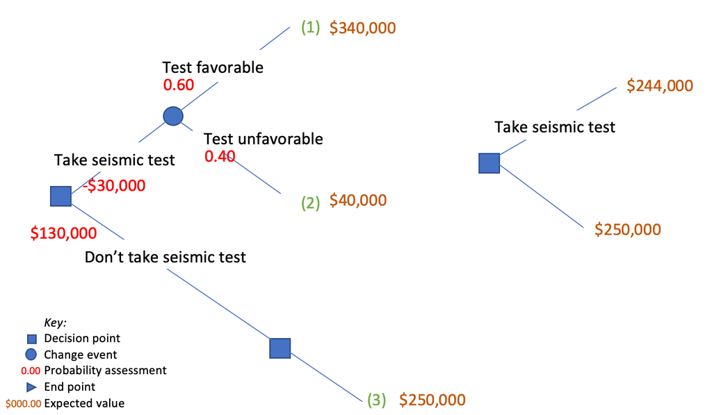

### Análisis

Especulemos ahora sobre cómo podría reaccionar Snyder a estos resultados. Seguramente le complace que el valor esperado de su posición de activos después de la perforación inmediata sea de $250,000, mucho más que no hacer nada y quedarse con una posición de activos segura de $130,000. Además, estaría muy complacido si encontrara petróleo y terminara con $430,000 en activos. Sin embargo, está bastante preocupado por el hecho de que existe una probabilidad de .45 de que termine con solo $30,000 en activos, lo que, a efectos prácticos, lo dejaría fuera del negocio (ver árbol con flujos de dinero).

Snyder luego analiza la estrategia “Realizar una prueba sísmica y perforar solo si es favorable”. Aunque tiene un valor esperado ligeramente más bajo que la opción elegida ( $244,000 versus $250,000), señala que la posibilidad de terminar con una posición de activos baja se reduce considerablemente, de .45 a .09 (es decir, .60 ×. 15). Como muchos empresarios, es conservador. De hecho, debido a la débil posición financiera de su empresa, es extremadamente conservador y es bastante escéptico sobre el curso de acción recomendado por este modo de análisis. Su intuición le dice que debe realizar la prueba sísmica, pero este análisis de decisión le dice que está equivocado.

Snyder, como muchos hombres de negocios, está atrapado en un dilema. Dado que la incertidumbre es un factor importante en su decisión, es consciente de la necesidad de reconocerla explícitamente en su análisis; y ha estructurado correctamente su análisis con un árbol. Siente que ha evaluado correctamente las consecuencias económicas de diversas contingencias. También siente que las probabilidades utilizadas en su análisis reflejan su mejor juicio sobre las posibilidades de que los eventos realmente ocurran. Sin embargo, su intuición parece decirle que la conclusión del análisis no es para él.

## Otra alternativa

Retomando el árbol de decisión y las tres principales decisiones, podemos encontrar el valor esperado para estas tres decisiones:

1. Taladrar inmediatamente $E_1$,

3. Dejar que la opción que le den caduque (no hacer nada) $E_3$.

$$E_3 = 130,000$$

Aquí ya estamos incluyendo el riesgo, por medio de las probabilidades de cada una de las decisiones, según todo el análisis anterior *¿qué le recomendarías a Snyder?*

# Práctica No. 3

Laura tiene planeado irse de vacaciones al extranjero el próximo mes. Para ello, ha escogido tres alternativas: Colombia, Panamá y Guatemala. Ella quiere escoger la decisión que le permita tener menor costo.

Para tomar la decisión, ella ha observado que las variables como el dólar y el clima afectarán sus decisiones. Si el dólar está alto, el costo estimado del viaje a Colombia será de US 850, Panamá US 900 y Guatemala US 750. Por el contrario, si el dólar está bajo, el costo cambia a US 500, US 400 Y US 450, respectivamente. Ahora, también si clima está soleado, el costo disminuirá en un 15% y si está lluvioso aumentará en US 75.

Sabiendo que, la probabilidad de que el dólar esté alto es de 0.7 y que la probabilidad de que el clima sea soleado es de 0.6 en Colombia, 0.8 en Panamá y 0.4 en Guatemala:

1. ¿Define cuál es el nodo de decisión principal?
2. Construye un árbol de decisión para este problema
3. Por medio del valor esperado, ayuda a Laura a tomar la mejor decisión, ¿Dónde le recomiendas viajar?

Subir en PDF a canvas tus resultados.